# Weather 2024

Author

Maris Pärn

## Exploration of weather data from MetNo

What was the weather like in summer-autumn 2024? Using hourly data (only acquired for detector running times, not 24h). One hour (20.08.24 22:00) interpolated. Temperature, air pressure, cloud area, humidity and wind speed aquired through linear interpolation. Wind direction found with circular interpolation and precipitation listed as 0 to all the sites based on neighboring hours.

### Temperature

Here we’ll see what the temperatures are like around the sites. The sites are arranged from north to south and on Figure 1 we can see that the mean temperatures (dark lines) are similar throughout the study area. To further highlight some outliers, we see on Figure 2 that CM-07 has lower mean temperature during the detector work times and CM-01 and CM-02 have more stable temperatures as they are the only 2 locations on an island (Utsira). CM-07 is an inland site located in a W-E facing valley.

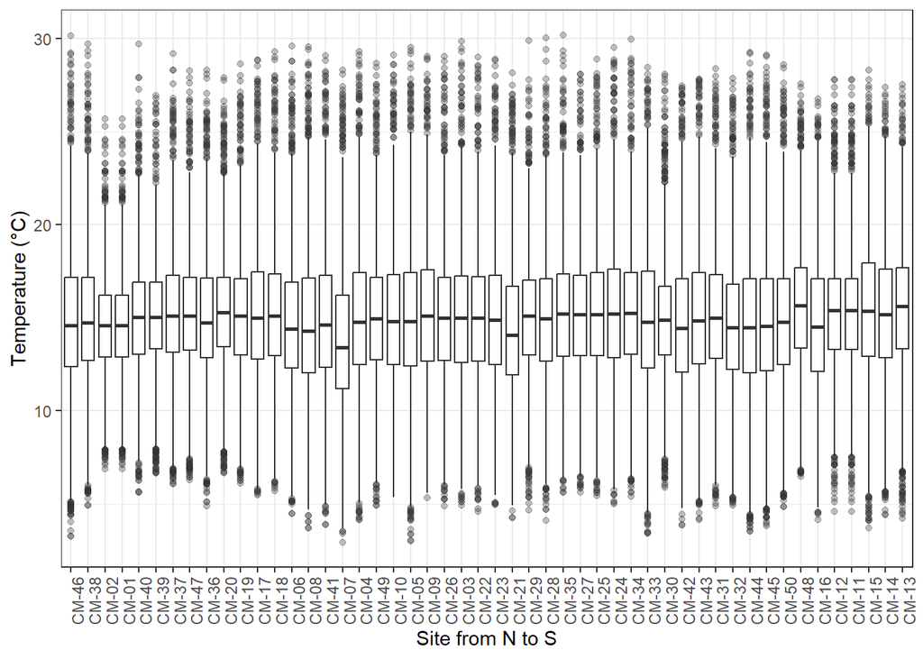

Figure 1: Temperature differences between sites

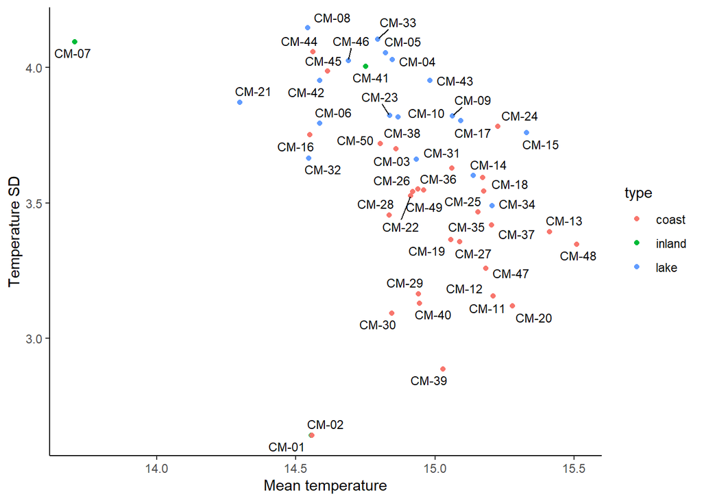

Figure 2: Mean temperature at the sites

Throughout the season, we can see on Figure 3 that the temperature has a sudden drop in September, after a storm hit the region.

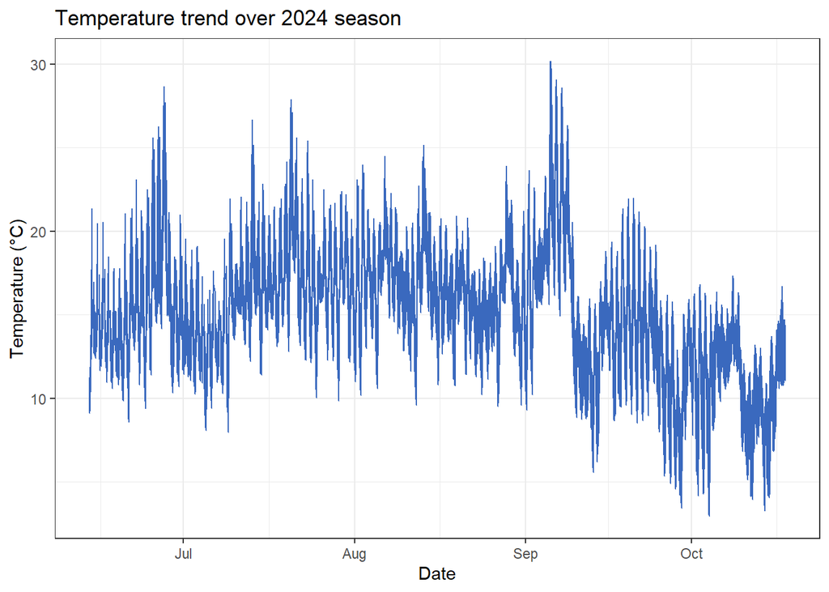

Figure 3: Temperature trend throughout 2024 season

### Wind

The Southwestern part of Norway is known as a very windy area, the maximum and mean wind speed graphs support that claim with coastal sites showing higher mean and max wind speeds.

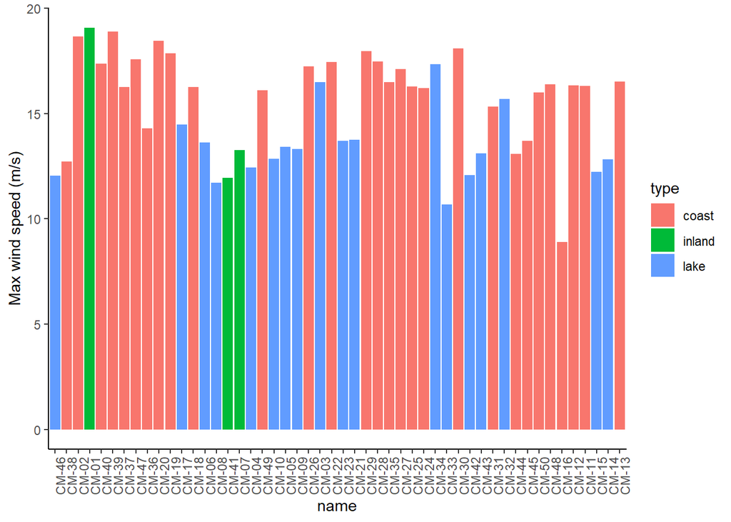

Figure 4: Maximum wind speed on the sites

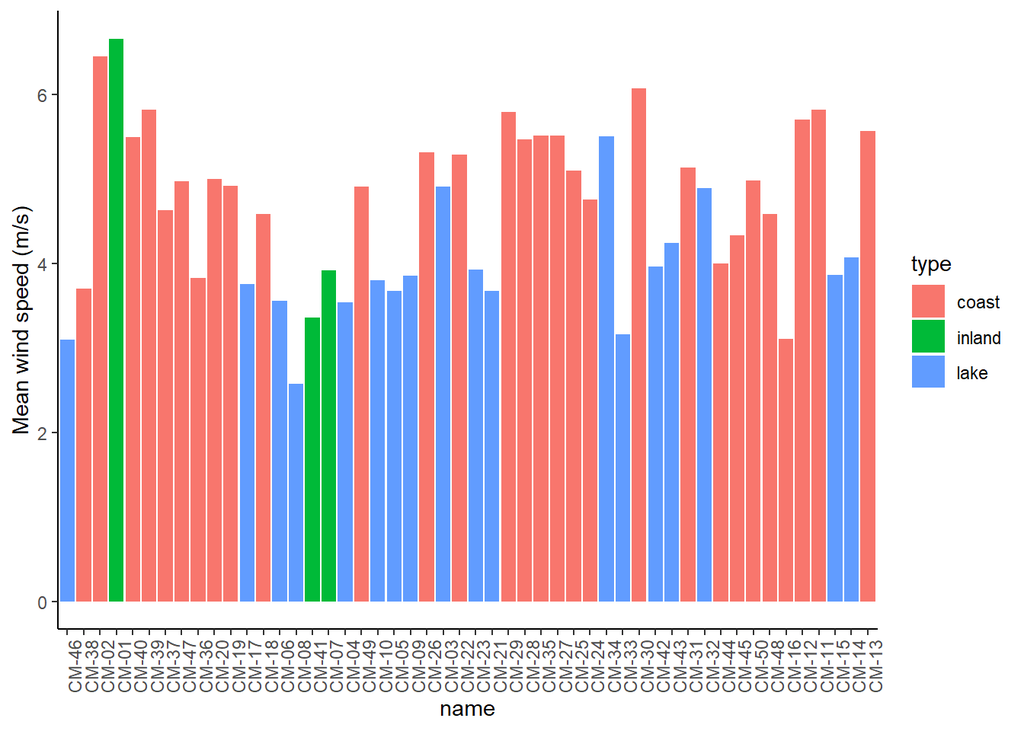

Figure 5: Mean wind speed on the sites

When we look at the wind direction in the whole research area, we can see the difference in the summer months and autumn, as the wind changes direction towards autumn.

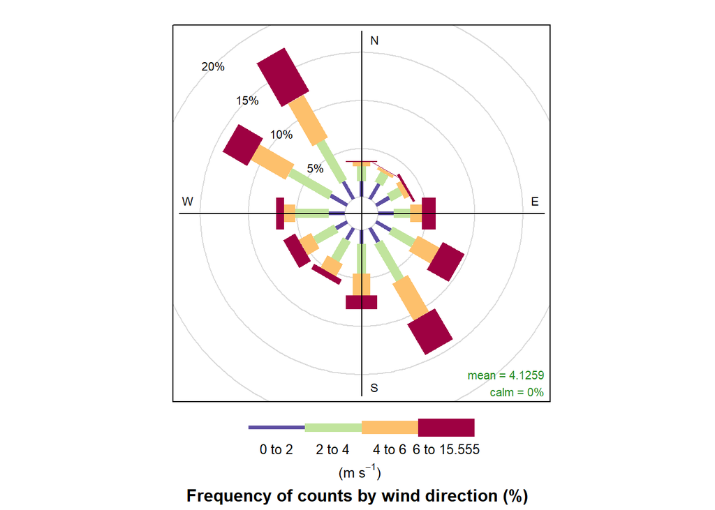

(a) Wind direction in June-July

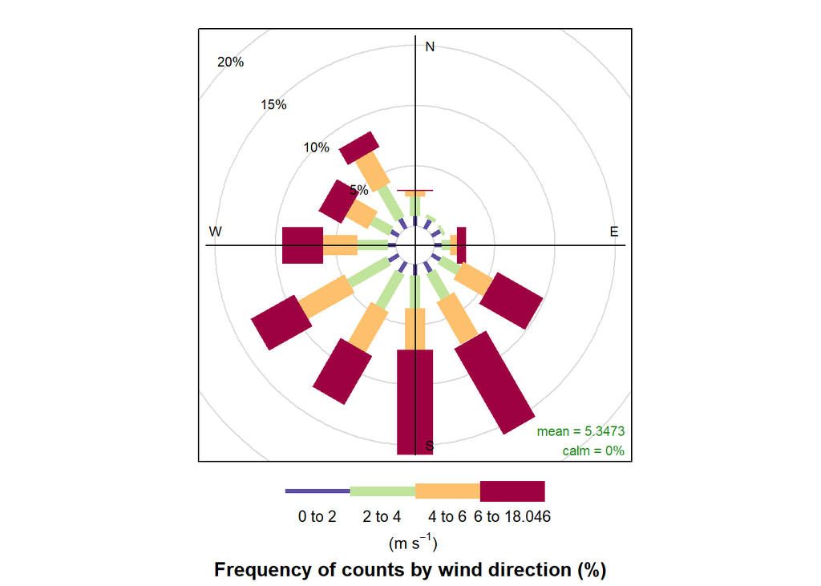

(b) Wind direction in August

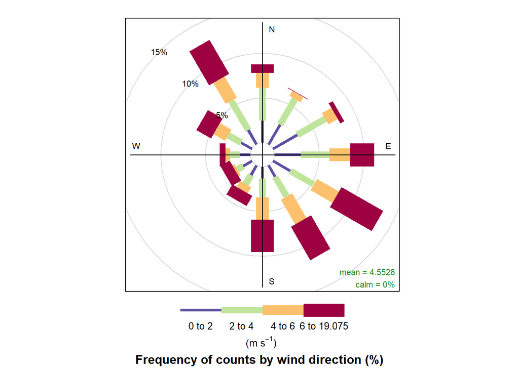

(c) Wind direction in September

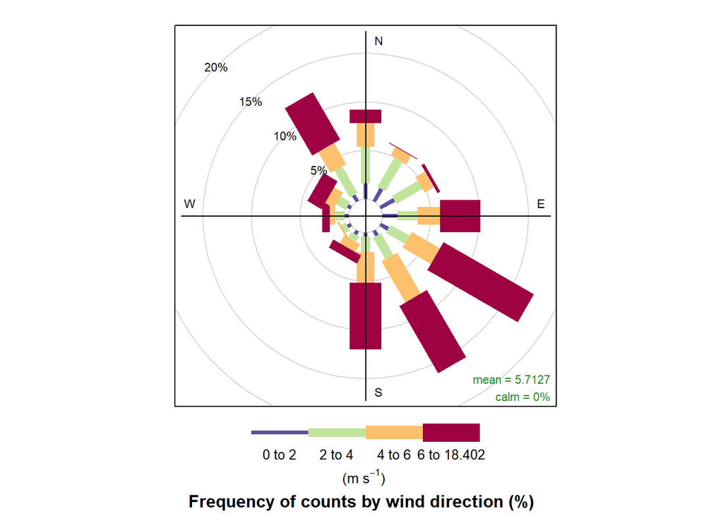

(d) Wind direction in October

Figure 6: Comparison of wind direction by month

### Precipitation

When we look at the precipitation during the detector recording period, we can see that about 15% of the recording hours, it was raining more than 0,1 mm per hour. On Figure 7 we can see a difference in the southern locations and other locations in the study area, with the south (Lista peninsula) having the least amount of rainfall hours.

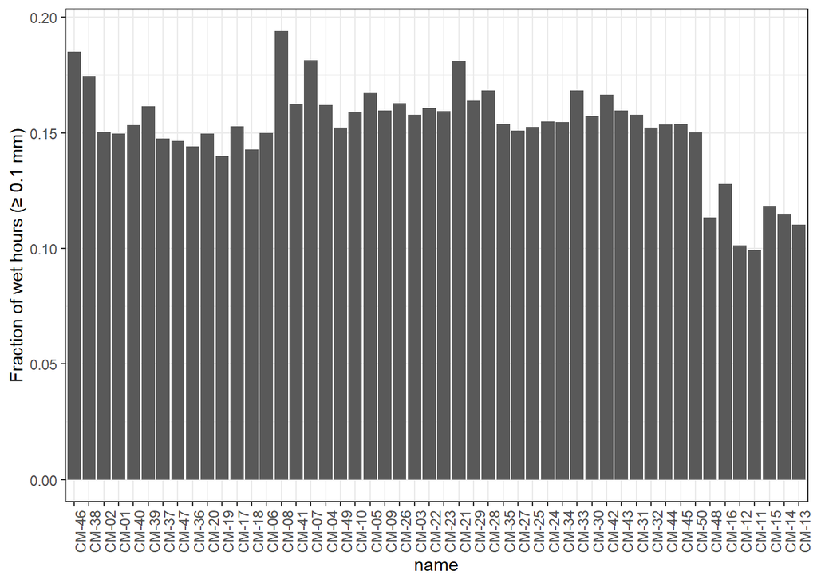

Figure 7: The fraction of wet hours during the recording period in 2024

When we look at how much it rained nightly in the study area on Figure 8, then we can see some periods without rain, but also a lot of long rainy periods.

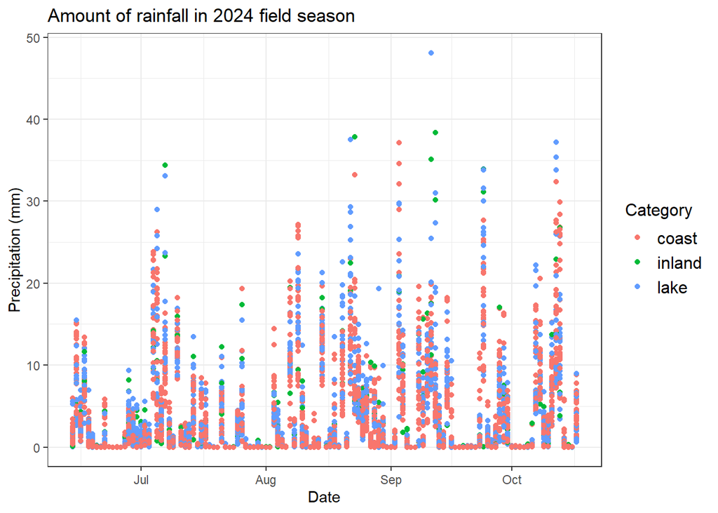

Figure 8: Overall rainfall in 2024

### Other parameters

There is also data about cloud area fraction and air pressure for the study area. From total cloud coverage by study sites, on Figure 9 we can see that northern sites seem to have more cloud coverage than the southern sites.

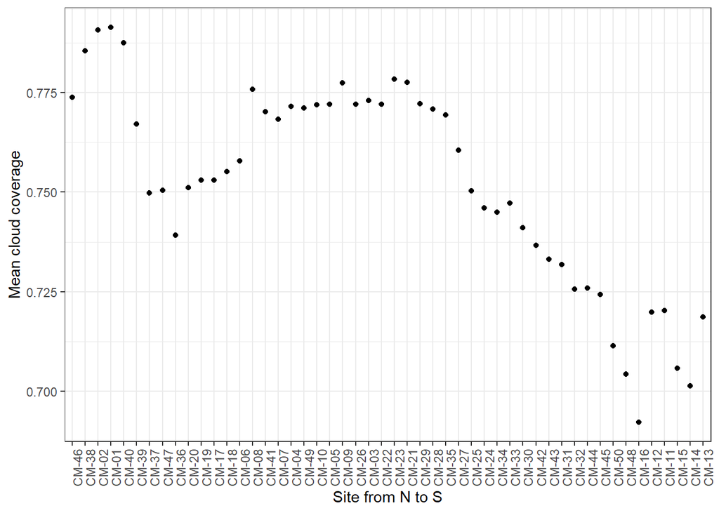

Figure 9: Cloud coverage change in 2024

Air pressure change is constant in the region, with more amplitude further in the season.

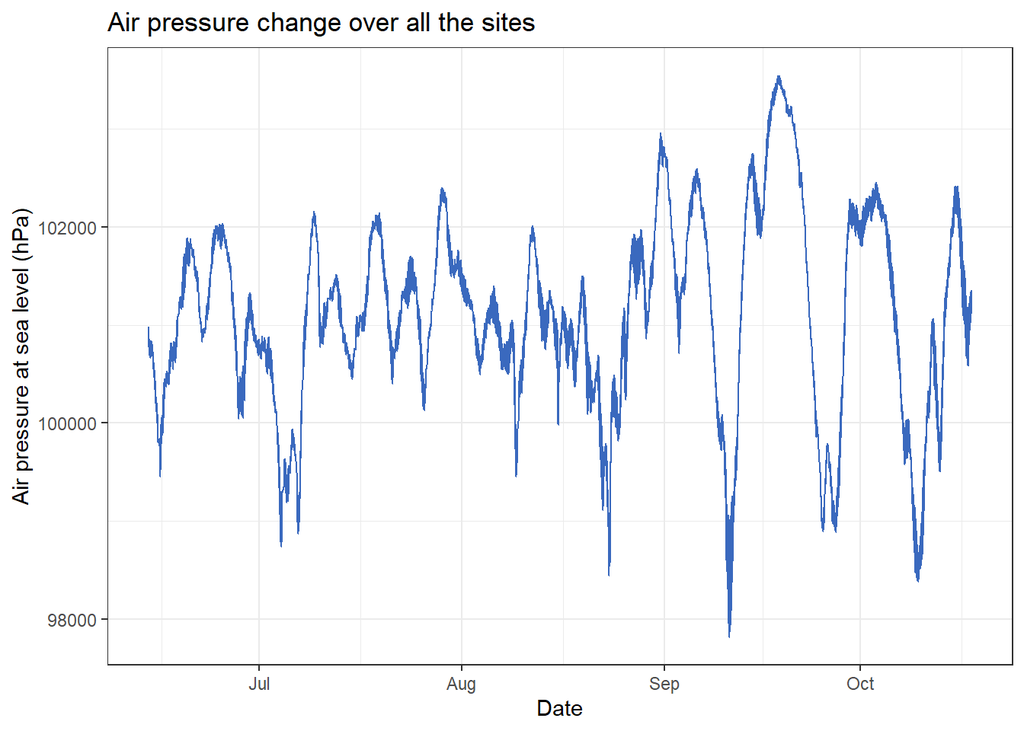

Figure 10: Air pressure change in 2024